# Project 4

## Project 4 - MISY408

**Load bike-sales CSV File into df dataframe and display the first 5 rows**

```python
import pandas as pd
df = pd.read_csv('bike-sales.csv')
df.head()
```

|  | Date | Customer_Age | Age_Group | Customer_Gender | Country | State | Product_Category | Sub_Category | Product | Order_Quantity | Unit_Cost | Unit_Price | Profit | Cost | Revenue |
| --- | --- | --- | --- | --- | --- | --- | --- | --- | --- | --- | --- | --- | --- | --- | --- |
| 0 | 11/26/2013 | 19 | Youth (<25) | M | Canada | British Columbia | Accessories | Bike Racks | Hitch Rack - 4-Bike | 8 | 45 | 120 | 590 | 360 | 950 |
| 1 | 11/26/2015 | 19 | Youth (<25) | M | Canada | British Columbia | Accessories | Bike Racks | Hitch Rack - 4-Bike | 8 | 45 | 120 | 590 | 360 | 950 |
| 2 | 3/23/2014 | 49 | Adults (35-64) | M | Australia | New South Wales | Accessories | Bike Racks | Hitch Rack - 4-Bike | 23 | 45 | 120 | 1366 | 1035 | 2401 |
| 3 | 3/23/2016 | 49 | Adults (35-64) | M | Australia | New South Wales | Accessories | Bike Racks | Hitch Rack - 4-Bike | 20 | 45 | 120 | 1188 | 900 | 2088 |
| 4 | 5/15/2014 | 47 | Adults (35-64) | F | Australia | New South Wales | Accessories | Bike Racks | Hitch Rack - 4-Bike | 4 | 45 | 120 | 238 | 180 | 418 |

**Take a deep copy of df and save it to df1**

```python
df1 = df.copy()
```

**Import required libraries for visualization (matplotlib and seaborn)**

```python
import matplotlib.pyplot as plt
import seaborn as sns
```

**Question 1:**

**Explore the dataframe: the shape of the df1, the list of columns, check if there is any missing values**

```python
df1.shape
```

```
(113036, 15)
```

```python
df1.columns
```

```
Index(['Date', 'Customer_Age', 'Age_Group', 'Customer_Gender', 'Country',
       'State', 'Product_Category', 'Sub_Category', 'Product',
       'Order_Quantity', 'Unit_Cost', 'Unit_Price', 'Profit', 'Cost',
       'Revenue'],
      dtype='object')
```

```python
df1.isnull().sum()
```

```
Date                0
Customer_Age        0
Age_Group           0
Customer_Gender     0
Country             0
State               0
Product_Category    0
Sub_Category        0
Product             0
Order_Quantity      0
Unit_Cost           0
Unit_Price          0
Profit              0
Cost                0
Revenue             0
dtype: int64
```

**Question 2:**

**Generate the descriptive statistics to show count, mean, std, min, max, and etc. of numeric columns in the df1 dataframe**

```python
df1.describe()
```

|  | Customer_Age | Order_Quantity | Unit_Cost | Unit_Price | Profit | Cost | Revenue |
| --- | --- | --- | --- | --- | --- | --- | --- |
| count | 113036.000000 | 113036.000000 | 113036.000000 | 113036.000000 | 113036.000000 | 113036.000000 | 113036.000000 |
| mean | 35.919212 | 11.901660 | 267.296366 | 452.938427 | 285.051665 | 469.318695 | 754.370360 |
| std | 11.021936 | 9.561857 | 549.835483 | 922.071219 | 453.887443 | 884.866118 | 1309.094674 |
| min | 17.000000 | 1.000000 | 1.000000 | 2.000000 | -30.000000 | 1.000000 | 2.000000 |
| 25% | 28.000000 | 2.000000 | 2.000000 | 5.000000 | 29.000000 | 28.000000 | 63.000000 |
| 50% | 35.000000 | 10.000000 | 9.000000 | 24.000000 | 101.000000 | 108.000000 | 223.000000 |
| 75% | 43.000000 | 20.000000 | 42.000000 | 70.000000 | 358.000000 | 432.000000 | 800.000000 |
| max | 87.000000 | 32.000000 | 2171.000000 | 3578.000000 | 15096.000000 | 42978.000000 | 58074.000000 |

**Question 3: Histogram**

**Use matplotlib to create the histogram of Cost.**

- Use matplotlib (plt.) to add title: 'Cost vs. Frequency of Cost', add x label: 'Cost' and y label: 'Frequency of Cost'.

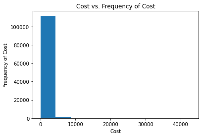

```python
plt.title('Cost vs. Frequency of Cost')
plt.xlabel('Cost')
plt.ylabel('Frequency of Cost')
plt.hist(df1['Cost'])
plt.show()
```

**Question 4:**

**Use Seaborn to create a scatter plot of Cost vs. Profit.**

- Put Cost on x-axis and Profit on y-axis.
- Use Seaborn to add title. The title should be 'Cost vs. Profit'.

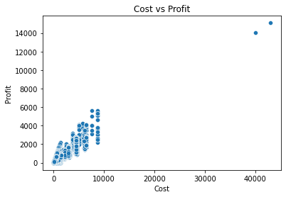

```python
sns.scatterplot(x=df1['Cost'], y=df1['Profit']).set_title('Cost vs Profit')
```

**Question 5:**

**a. Use Seaborn to create a scatter plot of Cost vs. Profit and add regression line to show strength of the relationship.**

- Put Cost on x-axis and Profit on y-axis.
- Use Seaborn to add title. The title should be 'Cost vs. Profit'.

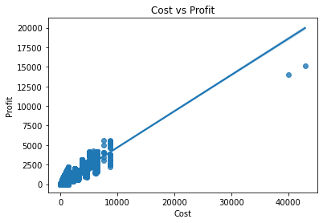

```python
sns.regplot(x=df1['Cost'], y = df1['Profit']).set_title('Cost vs Profit')
```

**Question 6:**

**Use Seaborn to create a scatter plot of Cost vs. Profit.**

- Change the color of dots by 'Product_Category'.
- Put Cost on x-axis and Profit on y-axis.
- Use Seaborn to add title. The title should be 'Cost vs. Profit'.
- Create your own palette and name it palette1. Accessories should be red, Clothing should be blue, and Bikes should be orange.

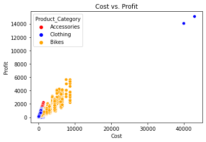

```python
palette1 = {'Accessories':'Red' , 'Clothing':'Blue' , 'Bikes':'Orange'}
sns.scatterplot(x=df1['Cost'], y=df1['Profit'], hue=df1['Product_Category'], palette = palette1).set_title('Cost vs. Profit')
```

**Question 7:**

**Use seaborn to create a scatter plot of Cost vs. Profit in 'Canada'.**

- Change the color of dots by 'Product_Category'.
- Put Cost on x-axis and Profit on y-axis
- Use Seaborn to add title. The title should be 'Cost vs. Profit in Canada'.
- Create your own palette and name it palette1. Accessories should be red, Clothing should be blue, and Bikes should be orange.

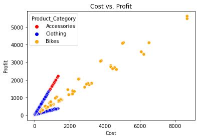

```python
palette1 = {'Accessories':'Red' , 'Clothing':'Blue' , 'Bikes':'Orange'}
df2=df1.loc[(df1['Country']=='Canada')].copy()
sns.scatterplot(x=df2['Cost'], y=df2['Profit'], hue=df2['Product_Category'], palette=palette1).set_title('Cost vs. Profit')
```

**Question 8:**

**Use .plot() to create a bar chart to show the number of orders in each 'Product_Category' .**

- Use matplotlib (plt.) to add title: 'Product_Category vs. Number of Orders', add x label: 'Product_Category' and y label: 'Number of Orders'.
- Add labels for each bar. The labels should show the number of orders with no decimal places
- Use seaborn's 'Set2' palette for the color of bars

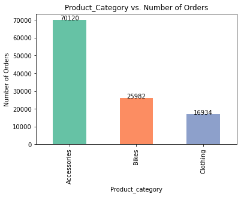

```python
plt.title('Product_Category vs. Number of Orders')
plt.xlabel('Product_category')
plt.ylabel('Number of Orders')

ax = df1['Product_Category'].value_counts()
ax.plot(kind='bar', color=sns.color_palette('Set2'))

for index, value in enumerate(ax):
    label = f'{value}'
    plt.text(index, value, label, ha = 'center')
```

**Question 9:**

**Use .plot() to create a bar chart to show average profit in each 'Product_Category' in Canada'.**

- Sort it in ascending order.
- Use seaborn's 'Set2' palette for the color.
- Use matplotlib (plt.) to add title:'Average profit in each Product_Category in Canada', x label:'Product_Category', and y label :'Average profit'.
- Add labels for each bar. The labels should show the average profit with 2 decimal places and should have $ sign.

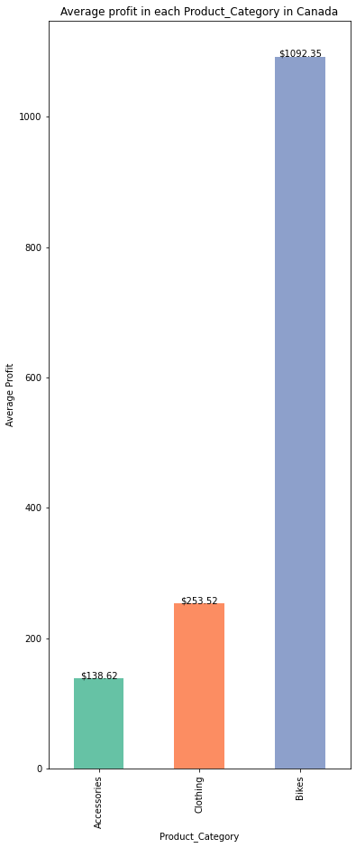

```python
plt.title('Average profit in each Product_Category in Canada')
plt.xlabel('Product_Category')
plt.ylabel('Average Profit')

df2 = df1.loc[(df['Country'] == 'Canada')].copy()
ax4 = df2['Profit'].groupby(df1['Product_Category']).mean().sort_values(ascending=True)

ax4.plot(kind = 'bar', color = sns.color_palette('Set2'))

for index, value in enumerate(ax4):
    label = f'${value:.2f}'
    plt.text(index, value, label, ha='center')

plt.subplots_adjust(top=3)
```

**Question 10:**

**Use .plot() to create a pie chart to show the percentage of orders for each 'Product_Category' in the 'United States'. Slices should have labels**.

- Use matplotlib (plt.) to add title. The title should be 'Percentage of orders in each Product_Category in the United States'.
- Make 'Clothing' product category in the pie chart to stand out by explode.
- Add Product_Category color legend to the upper right of the chart.
- Make sure the pie chart and it's labels do not overlap with color legend.

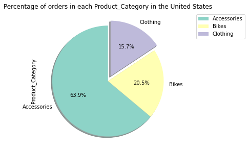

```python
df2 = df1.loc[(df1['Country'] == 'United States')].copy()
plt.title('Percentage of orders in each Product_Category in the United States')
explode_list = [0,0,0.1]
df2['Product_Category'].value_counts().plot(kind='pie',
                                            figsize = (5,5),
                                            autopct='%0.1f%%',
                                            startangle=90,
                                            shadow=True,
                                            explode = explode_list,
                                            colors = sns.color_palette('Set3'))
plt.legend(df2['Product_Category'].value_counts().index, loc = 'upper right', bbox_to_anchor=(1.5,1))
plt.show()
```

**Question 11:**

**Use Seaborn to create a countplot to show number of orders in each Product_Category.**

- Product_Category should be on x-axis.
- Change the color with Customer_Gender and use "rainbow" palette.
- Sort it in desending order.
- Add labels for each bar. The labels should show the number of orders.
- Use matplotlib (plt.) to add title:'Number of orders in each Product_Category', add x label: Product_Category and y label:Number of orders.
- Put the legend on upper right of the chart.
- Make sure the countplot does not overlap with color legend.

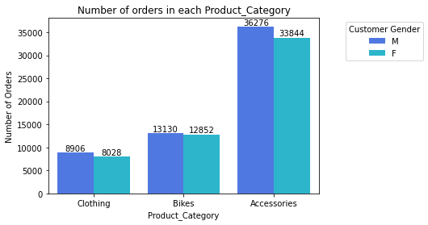

```python
ax1 = sns.set_palette('rainbow')
ax1=sns.countplot(x='Product_Category', data = df1, hue = 'Customer_Gender', order = df1['Product_Category'].value_counts().index.sort_values(ascending = False))
for container in ax1.containers:
    ax1.bar_label(container)
plt.title('Number of orders in each Product_Category')
plt.xlabel('Product_Category')
plt.ylabel('Number of Orders')
plt.legend(title='Customer Gender',loc='upper right',bbox_to_anchor=(1.4,1))
plt.show()
```

**Question 12:**

**Use .plot() to create a line plot to show average Profit in different years.**

- Use matplotlib (plt.) to add title:'Average profit in different years', add x label: 'Year' and y label:'Average profit'.

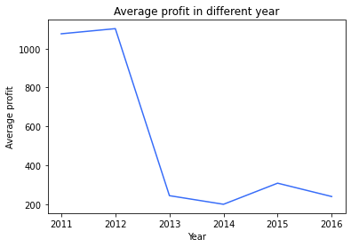

```python
df1['Date']= pd.to_datetime(df1['Date'])
df1['Year']=df1['Date'].dt.year
df1.groupby(df1['Year'])['Profit'].mean().plot(kind='line')
plt.title('Average profit in different year')
plt.xlabel('Year')
plt.ylabel('Average profit')
plt.show()
```

**Question 13:**

**Use Seaborn .lineplot() to create a line plot to show average Profit in different years.**

- Change the color of lines with Product_Category
- Use matplotlib (plt.) to add title:'Average profit in different years', add x label: 'Year' and y label:'Average profit'.
- Year should be on x-axis. Average profit should be on y-axis.
- Show the legend on the upper right of the chart

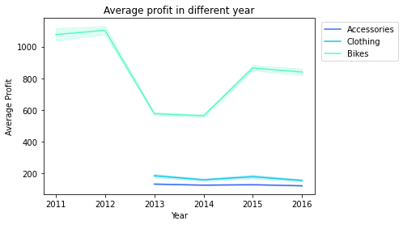

```python
df1['Date']= pd.to_datetime(df1['Date'])
df1['Year']=df1['Date'].dt.year
sns.lineplot(x=df1['Year'], y=df1['Profit'], hue = df1['Product_Category'], estimator='mean')
plt.title('Average profit in different year')
plt.xlabel('Year')
plt.ylabel('Average Profit')
plt.legend(bbox_to_anchor=(1.01,1), loc=2)
plt.show()
```

**Question 14:**

**Use Seaborn to create a Boxplot of 'Profit' for different 'Product_Category' in 'Ohio', in 'United States' and after 2015-01-01.**

- Use seaborn 'rainbow' palette
- Use matplotlib (plt.) to add title:'Boxplot of Product_Category vs. Profit'

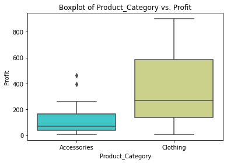

```python
df1['Date']= pd.to_datetime(df1['Date'])
df1['Year']=df1['Date'].dt.year
df1['Month']=df1['Date'].dt.month_name()
sns.boxplot(data=df1[(df1['State']=='Ohio')&(df1['Country']=='United States')&
                     (df1['Date']>'2015-01-01')], x='Product_Category', y ='Profit', palette='rainbow')
plt.title('Boxplot of Product_Category vs. Profit')
plt.show()
```